# Analyze scRNA from Song G et al 2022

scRNA re-analysis of [Song G. et al. 2022](https://doi.org/10.1038/s41467-022-29164-0)

## Data import

These data can be accessed by connecting with the authors of that manuscript. We thank Dr. Guohe Song for giving us access.

```r
suppressWarnings(
suppressPackageStartupMessages({

library(dplyr)
library(data.table)
library(tibble)
library(openxlsx)
library(tidyr)
library(stringr)
library(Seurat)
library(SeuratObject)
library(AUCell)
library(ggplot2)
library(ggrepel)
library(PNWColors)
library(cowplot)
library(gghalves)

})
)

packageVersion('Seurat')
```

```
## [1] '5.3.0'
```

```r
packageVersion('AUCell')
```

```
## [1] '1.30.1'
```

```r
'%ni%' <- function(x,y)!('%in%'(x,y))

code.dir = '~/Documents/scripts/github/btc-ccs/'
data.dir = '~/Documents/scripts/github/btc-ccs-data/'

source(paste0(code.dir,"/bin/BTC.functions.R"))
source(paste0(code.dir,"/bin/scrna_fxn.R"))

this.cohort = 'song_2022'
main_dir <- file.path(data.dir, '/source_data/scrna/',this.cohort)
setwd(main_dir)

save.ind.nonepi = F
if(save.ind.nonepi){
  noepi <- readRDS(file.path(data.dir,'source_data/scrna/song_2022/nonepi.rds'))
  no.epi.tumours <- unique(noepi@meta.data[,'orig.ident'])[grepl("T$", unique(noepi@meta.data[,'orig.ident']))]

  for(this.sample in no.epi.tumours){

    noepi.sub <- subset(noepi, subset = orig.ident == this.sample)

    noepi.sub <- SCTransform(noepi.sub, verbose = FALSE, method = "glmGamPoi")
    noepi.sub$cellmeta <- 'noepi'

    if (!dir.exists(paste0(data.dir,'source_data/scrna/song_2022/infercnv/',this.sample))) {
      dir.create(paste0(data.dir,'source_data/scrna/song_2022/infercnv/',this.sample), recursive = T)
    }

    saveRDS(noepi.sub, paste0(data.dir,'source_data/scrna/song_2022/infercnv/',this.sample,'/nonepi.',this.sample,'.rds'))

  }
}

song.epi <- readRDS(file.path(data.dir,'/source_data/scrna/song_2022/epi.rds'))

song.epi <- SCTransform(song.epi, verbose = FALSE)
#I19T makes everything crash
song.epi <- subset(song.epi, subset = orig.ident %in% c('I02T', 'I03T', 'I04T', 'I06T', 'I09T', 'I10T',
                                                        'I12T', 'I13T', 'I14T', 'I15T',  'I16T', 'I17T', 'I18T'))
```

## Explore dataset at a high level

```r
song.epi <- RunPCA(song.epi)
```

```
## PC_ 1
## Positive:  SERPINA1, SPP1, CRP, ALB, APCS, FGG, DEFB1, VTN, CRYAB, C3
##     FGA, CXCL8, CXCL2, FXYD2, FGB, IGFBP1, NNMT, RGS5, CITED4, FN1
##     CLDN10, ORM1, AMBP, KRT23, CYR61, CXCL6, ITIH2, CCL20, AGT, NEB
## Negative:  TFF1, AGR2, TFF3, REG4, S100A4, TFF2, PSCA, IFI27, S100P, TSPAN8
##     PHGR1, SPINK4, CEACAM5, MUC5AC, FXYD3, APOL1, CD55, PCCA, PRSS2, CD9
##     KRT19, MUC1, SFRP2, MUC2, SLC2A1, CLDN18, HSPA6, GPRC5A, CEACAM6, REG1A
## PC_ 2
## Positive:  PSCA, S100A4, SPINK1, IFI27, APOL1, MUC1, TSPAN8, FXYD3, DKK1, C15orf48
##     MSLN, TXNIP, UPK1B, MIA, APOL2, GABRP, CLDN18, KRT17, CAPN8, KRT19
##     AC005550.2, TYMP, AL365226.2, LGALS2, PLAC8, CYSTM1, VNN1, FAM3D, B2M, ADH1C
## Negative:  TFF3, SPINK4, REG1A, PCCA, PRSS2, TFF2, SFRP2, REG4, MUC2, CEACAM5
##     AGR2, HSPA6, TFF1, MUC5AC, IGFBP2, HSPA1B, MUC6, CD9, AQP3, HSPA1A
##     CD55, MT1G, ODC1, HES6, IGLC2, IGKC, MT1X, RASD1, UBE2C, RRM2
## PC_ 3
## Positive:  SERPINA1, ALB, SPINK1, VTN, FGA, SPP1, FGB, GC, A2M, C3
##     LCN2, REG1A, IGFBP2, FGG, CFH, RGS5, AGR2, CP, CLDN10, NEB
##     FN1, AMBP, FGL1, MUC5B, NPW, CRP, LYZ, ITIH2, SERPINB3, C8G
## Negative:  CRYAB, ID4, AKR1C1, JUN, ATF3, PCSK1N, FOSB, CXCL2, ID3, CCL2
##     IGFBP7, NUPR1, ANGPTL1, SOX4, MALAT1, PDGFD, DUSP1, ZBTB20, VIM, DCDC2
##     HES1, ANKRD1, DNAJB4, KLF2, JUND, RPS20, APBB1IP, EGR1, PTH2R, TUBA1A
## PC_ 4
## Positive:  CRP, FGG, APCS, FGB, FGA, LCN2, SPINK1, GC, NNMT, REG1A
##     C1S, RBP4, CFH, CP, C3, FGL1, CXCL2, ORM1, CD74, HLA-DRB1
##     SERPINB3, MUC5B, CFB, CFHR1, C1R, REG3A, CRYAB, DUOXA2, HLA-DRA, LBP
## Negative:  RGS5, NEB, VTN, SERPINA1, CITED4, GAMT, FN1, TCIM, SYT8, CTSH
##     KRT7, IL18, APOH, GP2, LGALS4, ITIH2, CLDN9, SCTR, TTYH1, LGALS3
##     SGCB, TESC, FMO5, RBP1, MEAF6, KRT23, HIST1H4C, S100A14, ALB, TMSB10
## PC_ 5
## Positive:  KRT81, SERPINA1, NDUFA4L2, FN1, PTGDS, CCL20, LGALS1, ANXA1, CDKN2A, IGFBP1
##     TMEM45A, KRT17, THBS1, CP, S100A2, MT2A, MUC16, PLAT, TIMP3, LY6D
##     FBLN1, CSTB, FXYD2, LAMC2, MXRA8, TGM2, IGFBP3, LAMA3, AREG, DCBLD2
## Negative:  VTN, RGS5, SPINK1, NEB, APCS, CRYAB, AMBP, CITED4, LYZ, TCIM
##     LGALS4, FGG, CRP, CYB5A, AKR1C1, JUN, GAMT, TFF1, AGT, ATF3
##     TSPAN8, RBP4, ADH1C, PSCA, AGR2, CA2, LGALS2, CYR61, SERPING1, GP2
```

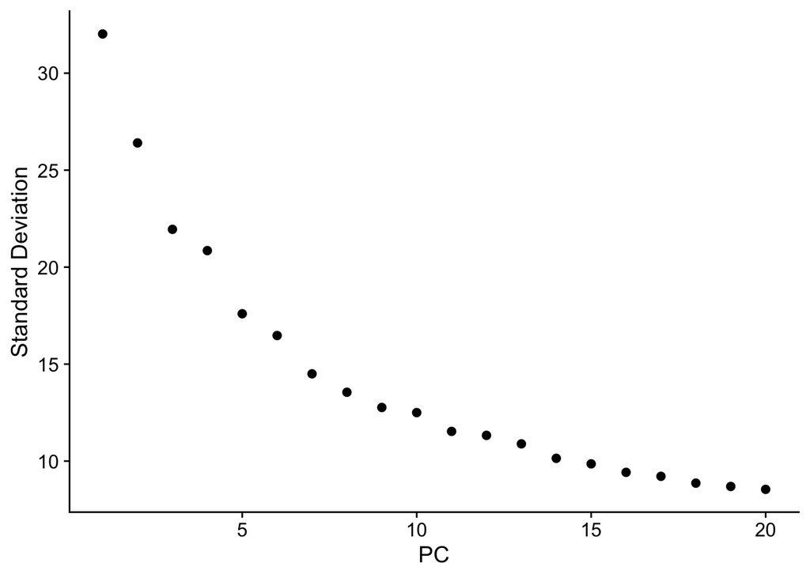

```r
ElbowPlot(song.epi) # determining the number of dimensions to use to find neighbours
```

```r
song.epi <- FindNeighbors(song.epi, dims = 1:15)
song.epi <- RunUMAP(song.epi, dims = 1:15)
```

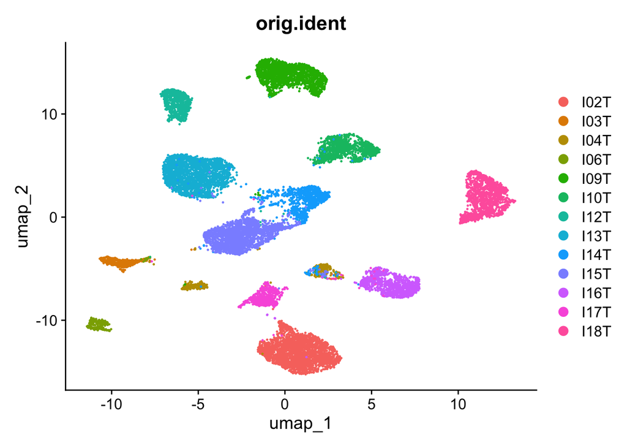

```r
DimPlot(song.epi, reduction = "umap", group.by = "orig.ident")
```

## Project NMF signatures onto cells with AUCcell

We are mostly interested in the scRNA data because NMF decomposition does not necessarily resolve single cells, so we combine the two approaches. There’s quite a bit of manual parametrization here again. The first is that we are transiting from gene weights from the NMF to gene lists for AUCcell. So we take the distribution of weights from the NMF and fit a bimodal distribution with mcclust using our make_gene_sets() function, most genes have small weights so are discarded in this step. However, the genesets were still highly correlated with just the removal of low weight genes (see corplot) so we go one step further and subset to the nth-tile of the distribution (in this case 90th percentile).

```r
y_order.convert <- fread( file.path(data.dir,'/results/whole.NMF.conversion.txt' ))
y_order.convert$og <- gsub('sig','V', y_order.convert$og)

w.matrix <- read.csv(file.path(data.dir,'/results/whole.W_matrix.txt'), row.names= 1)
genes <- row.names(w.matrix)
w.matrix <- w.matrix %>% dplyr::select(all_of(y_order.convert$og))
names(w.matrix) <- y_order.convert$new
w.matrix <- as.matrix(w.matrix)
row.names(w.matrix) <- genes

gene_set <- fread(file.path(data.dir,'/source_data/fgs.txt'))
tpm_data <- convert_w_to_tpm_like(w.matrix, gene_set)
gene_sets <- make_gene_sets(tpm_data, ntile=0.9)
```

```
## sig.1
## sig.2
## sig.3
## sig.4
## sig.5
## sig.6
## sig.7
## sig.8
```

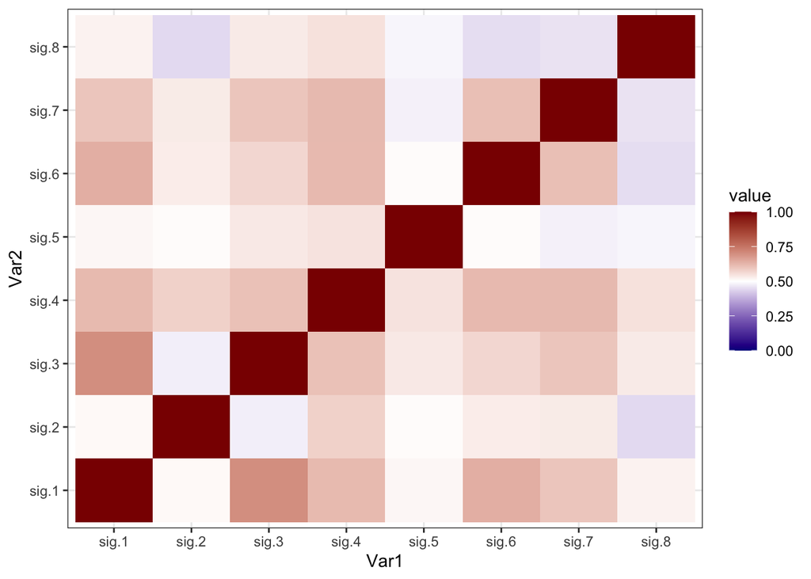

```r
setClass("ExpData", contains = "matrix")
expr_matrix <- GetAssayData(song.epi, assay = 'SCT', slot = 'data')

expr_matrix.nmf <- expr_matrix[rownames(expr_matrix) %in% unique(unlist(gene_sets)), ]

cells_rankings <- AUCell_buildRankings(expr_matrix.nmf)
```

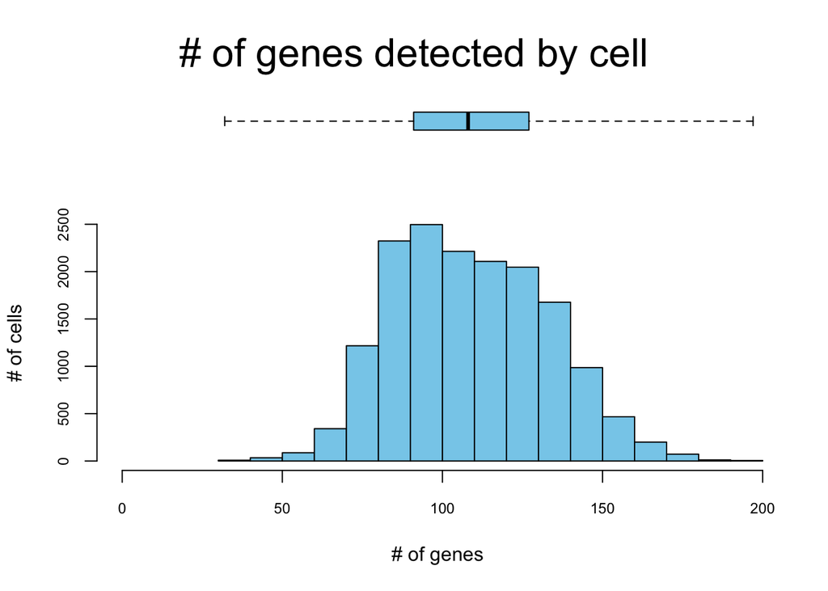

```
## Quantiles for the number of genes detected by cell:
## (Non-detected genes are shuffled at the end of the ranking. Keep it in mind when choosing the threshold for calculating the AUC).
```

```
##  min   1%   5%  10%  50% 100%
##   32   62   74   80  108  197
```

```r
nmf_AUC <- AUCell_calcAUC(gene_sets,
                          cells_rankings,
)
```

```
## Genes in the gene sets NOT available in the dataset:
##  sig.1:  114 (22% of 529)
##  sig.2:  193 (35% of 556)
##  sig.3:  89 (17% of 532)
##  sig.4:  110 (20% of 549)
##  sig.5:  120 (23% of 522)
##  sig.6:  118 (22% of 525)
##  sig.7:  108 (20% of 534)
##  sig.8:  117 (22% of 524)
```

## AUCcell thresholding

We found AUCcell results to be very impacted by thresholding so we left the paramters at default. Below is the fit of the NMF signatures across the scRNA cell population.

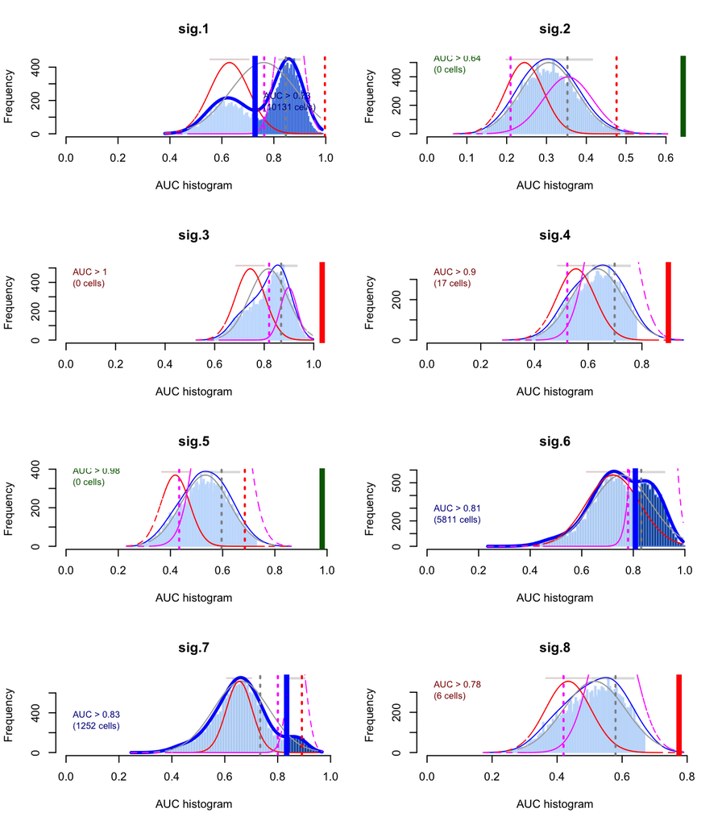

```r
## find thresholds
par(mfrow=c(4,2))
cells_assignment <- AUCell_exploreThresholds(nmf_AUC, plotHist=TRUE, nCores=1, assign=TRUE)
```

```r
par(mfrow=c(1,1))

auc_matrix <- as.data.frame(t(getAUC(nmf_AUC)))
auc_matrix <- auc_matrix[Cells(song.epi), ]

auc_matrix_zeroed <- auc_matrix

for(this.sig.index in c(1:length(unique(names(cells_assignment)))) ){
  this.sig <- paste0('sig.',this.sig.index)
  this.ass <- cells_assignment[[this.sig]]


  auc_matrix_zeroed[this.sig.index][auc_matrix_zeroed[this.sig.index] < this.ass$aucThr$selected] <- 0

}
```

## Visualize NMF signatures on umap

With our signatures assigned, we project them in UMAP space.

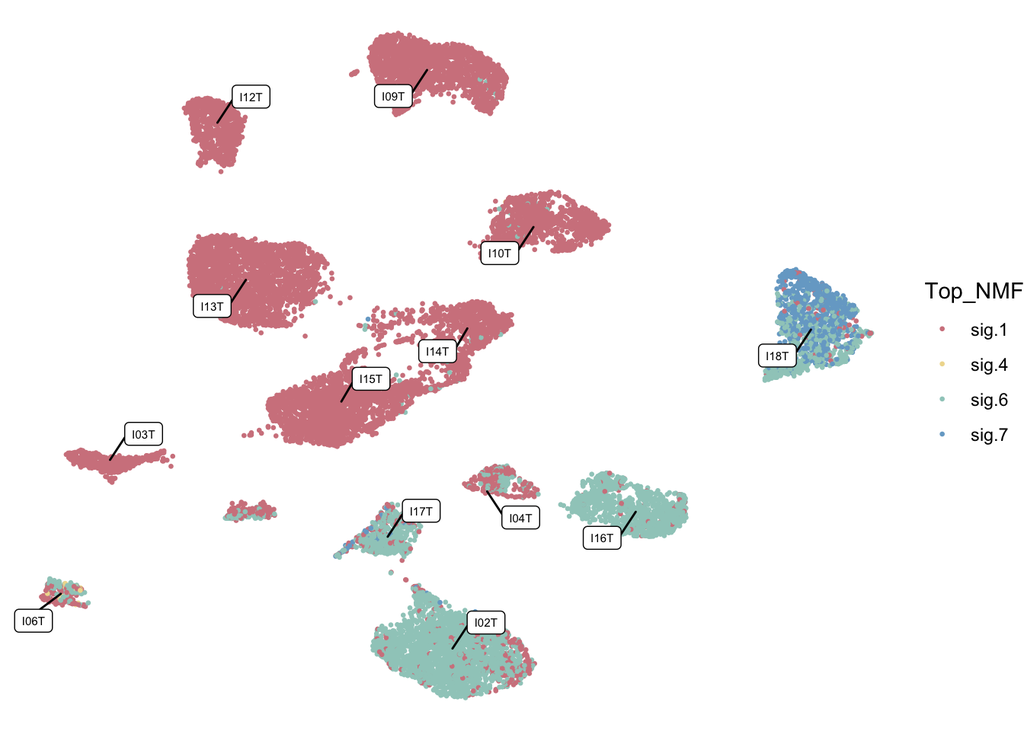

```r
song.epi <- AddMetaData(song.epi, metadata = auc_matrix_zeroed)

NMF_cols <- names(gene_sets)
song.epi$Top_NMF <- NMF_cols[max.col(song.epi@meta.data[, NMF_cols], ties.method = "first")]
scores <- song.epi@meta.data[, "Top_NMF", drop = FALSE]

emb <- Embeddings(song.epi, "umap") %>%   as.data.frame()

df <- bind_cols(emb, scores)
df <- cbind.data.frame(df, song.epi@meta.data[, NMF_cols])
df$donor <- song.epi@meta.data[, 'orig.ident']

centroids <- df %>%
  group_by(donor) %>%
  summarise(
    x_centroid = median(umap_1),
    y_centroid = median(umap_2)
  )

color.set <-    pnw_palette(name="Sailboat", n=8 )
names(color.set) <- paste0('sig.',c(8:1))

ggplot(df , aes(x = umap_1, y = umap_2)) +

  geom_point(size=0.5, aes(color = Top_NMF)) +
  geom_label_repel(data = centroids, aes(x = x_centroid, y = y_centroid, label = donor),
                   size=2,   box.padding = 0.5, force = 0.5, max.time = 4,  min.segment.length = 0, max.overlaps =15) +
  theme_void() +  # removes all axes and background
  scale_color_manual(values =
                       color.set, na.value = 'white'


  ) +

  theme(
    panel.border = element_blank(),
    plot.margin = margin(t = 0, r = 0, b = 0, l = 0),
    plot.background = element_blank()
  )
```

## infercnv

Now, let’s take our cells and infer the copy number profile from gene expression. Aneuploid cells are more likely to be malignant.

```r
run.infercnv=F

if(run.infercnv){

  library(infercnv)
  packageVersion('infercnv')
  library(Matrix)
  library(hdf5r)
  '%ni%' <- function(x,y)!('%in%'(x,y))
  options(scipen = 100)

  all_genes <- fread(file.path(data.dir,'/source_data/fgs.txt'))


  song.epi$cellmeta <- 'epi'

  these.samples <- unique(song.epi$orig.ident)
  #these.samples <- c('I19T')

  for(this.sample in these.samples){

    seurat_list <- list()

    seurat_list[['epi']] <- subset(song.epi, subset = orig.ident == this.sample)
    seurat_list[['noepi']] <- readRDS(paste0(data.dir,'/source_data/scrna/song_2022/infercnv/',this.sample,'/nonepi.',this.sample,'.rds'))

    features <- SelectIntegrationFeatures(seurat_list, nfeatures = 2000) # adjust number of features as needed

    seurat_list <- purrr::map(seurat_list, ~ RunPCA(.x, verbose = FALSE))

    seurat_list <- PrepSCTIntegration(seurat_list, anchor.features = features)

    anchors <- FindIntegrationAnchors(
      object.list = seurat_list,
      normalization.method = "SCT",
      anchor.features = features,
      reduction = "rpca",
      k.anchor = 10

    )


    combined <- IntegrateData(anchorset = anchors, normalization.method = "SCT")

    DefaultAssay(combined) <- "integrated"



    ref_group_names <- c("noepi")


    annotations <- data.frame(
      Cell = colnames(combined),
      Group = combined$cellmeta
    )

    write.table(annotations, paste0(data.dir,'/source_data/scrna/song_2022/infercnv/',this.sample,"/cellAnnotations.txt"),
                sep = "\t", row.names = FALSE, col.names = FALSE, quote = FALSE)

    gene_names <-  data.frame('gene_name'=rownames(combined@assays$RNA))

    gene_names <- left_join(gene_names, all_genes) %>% dplyr::select(gene_name, Chr,  Start,   End)
    duplicate.genes <- gene_names %>% group_by(gene_name) %>% tally() %>% arrange(desc(n)) %>% filter(n > 1)

    gene_names <- gene_names %>% filter(gene_name %ni% duplicate.genes$gene_name & !is.na(Chr) & Chr < 23) %>% arrange(Chr, Start,   End)

    write.table(gene_names, paste0(data.dir,'/source_data/scrna/song_2022/infercnv/',this.sample,"/geneAnnotations.txt"), sep = "\t", row.names = FALSE, col.names = FALSE, quote = FALSE)

    combined <- subset(combined, features = gene_names$gene_name)

    count_mat <- combined@assays$RNA$counts

    infercnv.obj <- CreateInfercnvObject(raw_counts_matrix = count_mat,
                                         annotations_file = paste0(data.dir,'/source_data/scrna/song_2022/infercnv/',this.sample,"/cellAnnotations.txt"),
                                         delim = "\t",
                                         ref_group_names = ref_group_names ,
                                         gene_order_file = paste0(data.dir,'/source_data/scrna/song_2022/infercnv/',this.sample,"/geneAnnotations.txt")
    )

    infercnv.res <- infercnv::run(infercnv.obj,
                                  # noise_filter = 0.2,
                                  # cutoff=0.5,
                                  out_dir=paste0(data.dir,'/source_data/scrna/song_2022/infercnv/',this.sample,"/output/"),
                                  cluster_by_groups=TRUE,
                                  denoise=TRUE,
                                  write_expr_matrix = T,
                                  no_plot=T,
                                  # num_threads=1,
                                  HMM=T
    )

    cnv_matrix <- data.frame(infercnv.res@expr.data)

    write.table( cnv_matrix,
                 file = paste0(data.dir,'/source_data/scrna/song_2022/infercnv/',this.sample,"/",this.sample,'.cnv_matrix.tsv'),
                 row.names = T,col.names = T, quote = FALSE, sep = "\t", append =F)

  }
}
```

## Predict gCCS from inferCNV profile

We use our gCCS model to predict the CCS of individual cells form the CNV profiles inferred from inferCNV

```r
cytoBand <- fread(file.path(data.dir,'/source_data/cytoBand.txt'), na.strings = '') %>%
  filter(!is.na(Chromosome))


cytoBand<- separate(cytoBand, col = Chromosome, into = c('band','period'), sep = '\\.', remove=F, extra = 'drop', fill='right')

cytoBand <- cytoBand %>%
  mutate(
    parts = str_match(band, "^(.*?[pq])(.*)$"),
    arm = parts[,2],
    armband = parts[,3]
  ) %>%
  dplyr::select(-parts) %>% filter(!is.na(arm) & arm %ni% c('Xq','Xp','Yp','Yq'))

full_cnv_model <- readRDS(file.path(data.dir,'/results/cnv.model.rds'))

first.sample = T
for(this.sample in unique(song.epi$orig.ident) ){

  infercnv.path <- paste0(data.dir,"/source_data/scrna/song_2022/infercnv/",this.sample,"/",this.sample,'.cnv_matrix.tsv')

  if(file.exists(infercnv.path)){

    cat('analyzing ', this.sample,'\n')

    suppressWarnings(

      infer.cnv.data <- fread(infercnv.path )

    )

    #get gCMS per cell

    segment.gene.cyto <- inner_join(cytoBand, infer.cnv.data,  by=c('Hugo_Symbol'='V1')) %>%
      dplyr::select(-c("Hugo_Symbol" , "Chromosome"  , "band" , "period" ,   "armband" ))

    ggplot(segment.gene.cyto, aes(x=band, y=))


    arm.med <- segment.gene.cyto %>%
      group_by(arm ) %>%
      summarise(across(where(is.numeric), \(x) median(x, na.rm = TRUE)))

    arm.med.t <- data.frame(t(arm.med[,-1]))
    arm.med.t <- log(arm.med.t, 2)
    names(arm.med.t) <- paste0('arm.',arm.med$arm)
    arm.med.t$mean.vaf <- 0.5

    arm.med.t$prob <- predict(full_cnv_model, arm.med.t, type = "response")

    #get cnv-score per cell
    arm.med.t$cnv_scores <- sqrt(colMeans(infer.cnv.data[,-1]^2, na.rm = TRUE))

    arm.med.t$barcode <-  rownames(arm.med.t)

    if(first.sample){cnv.loads <- arm.med.t; first.sample=F} else {cnv.loads <- rbind.data.frame(cnv.loads,  arm.med.t) }

  } else {

    cat('!!no infercnv profile for ',this.sample,'\n')

  }
}
```

```
## analyzing  I02T
## analyzing  I03T
## analyzing  I04T
## analyzing  I06T
## analyzing  I09T
## analyzing  I10T
## analyzing  I12T
## analyzing  I13T
## analyzing  I14T
## analyzing  I15T
## analyzing  I16T
## analyzing  I17T
## analyzing  I18T
```

```r
df$barcode <- rownames(df)

df.cnv <- left_join(df, cnv.loads, by=c('barcode'='barcode')) %>% filter(!is.na(mean.vaf))
```

## Visualize the effect of using the gCCS model

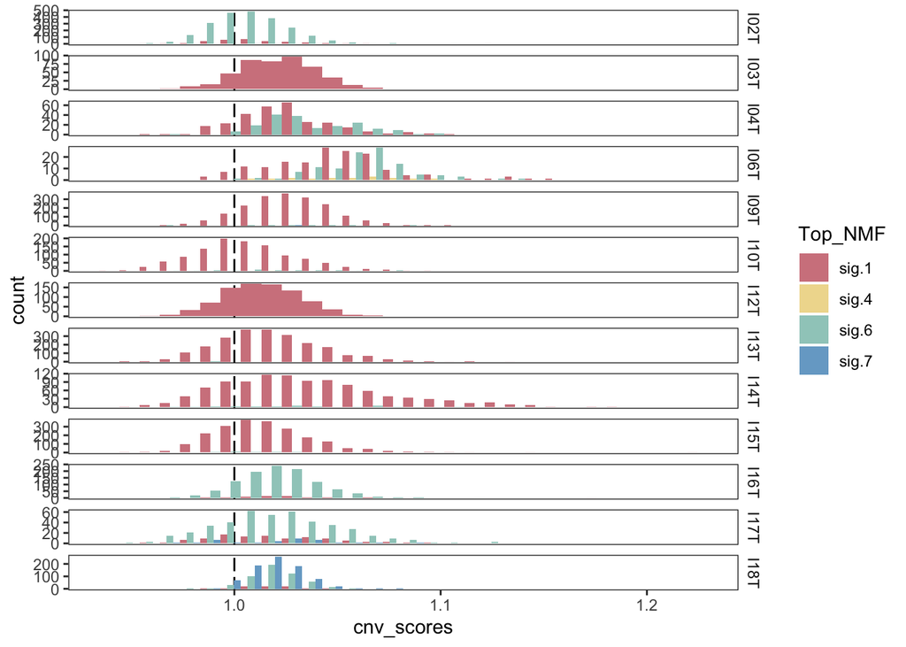

```r
ggplot(df.cnv , aes(x=cnv_scores, fill=Top_NMF)) +
  geom_vline(xintercept = 1, color="black",  linetype='longdash')+

  geom_histogram(position = position_dodge())+
  facet_grid(donor~., scales='free') +
  theme_bw()+
  theme(panel.grid=element_blank(),
        strip.background = element_blank()) +

  scale_fill_manual(values =
                      color.set, na.value = 'grey'
  )
```

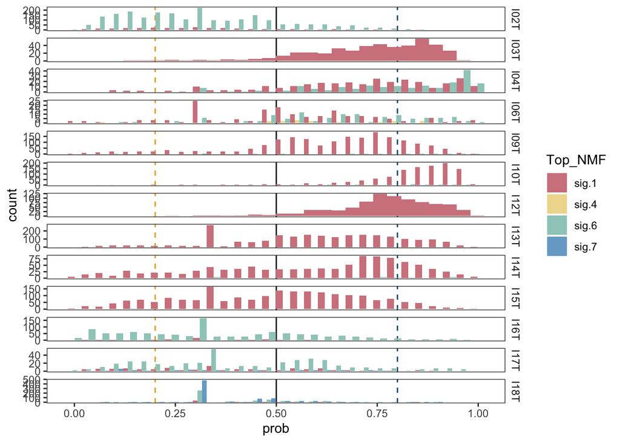

```r
THRESHOLD = 0.5

df.cnv$gCMS <- NA
df.cnv$gCMS[df.cnv$prob > 0.8 ] <- 'CCS-A'
df.cnv$gCMS[df.cnv$prob < 0.2 ] <- 'CCS-B'

ggplot(df.cnv %>% filter(!is.na(donor)), aes(x=prob, fill=Top_NMF)) +
  facet_grid(donor~., scales='free') +

  geom_vline(xintercept = THRESHOLD, color="black")+


  geom_vline(xintercept = 0.8, color="#04597C",  linetype='dashed')+
  geom_vline(xintercept = 0.2, color="#EDA71A",  linetype='dashed')+

  geom_histogram(position = position_dodge())+

  theme_bw()+
  theme(panel.grid=element_blank(),
        strip.background = element_blank()) +

  scale_fill_manual(values =
                      color.set, na.value = 'grey'
  )
```

```r
df.cnv.filt <- df.cnv
```

## eCCS

The TSP algorithm did not function at single cell resolution from high drop-out rates. So we calculate eCCS at the tumor-level from pseudo bulk. We bootstrap our pseudobulk estimate 100 to get a sense in our confidence of our assignment.

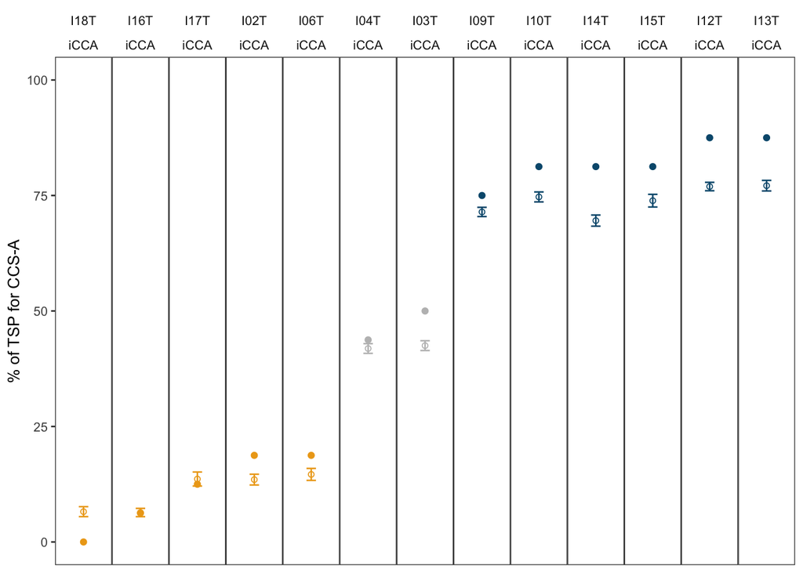

```r
tumour.subset_obj <- subset(song.epi, cells = df.cnv.filt$barcode)

whole.estimate <- get_cms_from_pseudobulk(tumour.subset_obj, grouping_var = "orig.ident",
                                    basedir = '~/Documents/scripts/github/btc-ccs-data/')

whole.estimate$sample_id <- rownames(whole.estimate)

meta <- tumour.subset_obj@meta.data
meta$cell <- rownames(meta)

for(this.boot in c(1:100)){

  seed=format(Sys.time(), "%OS3")
  set.seed(seed)

  sampled_cells <- meta %>%
    group_by(orig.ident) %>%
    slice_sample(n = 20, replace = F) %>%
    pull(cell)


  boot.subset <- subset(tumour.subset_obj, cells = sampled_cells)

  suppressMessages(
    boot.estimate <- get_cms_from_pseudobulk(boot.subset, grouping_var = "orig.ident",
                                    basedir = '~/Documents/scripts/github/btc-ccs-data/')
  )

  boot.estimate$sample_id <- rownames(boot.estimate)
  boot.estimate$boot <- this.boot

  if(this.boot == 1){all.boot.estimate <- boot.estimate}else{all.boot.estimate <- rbind.data.frame(all.boot.estimate, boot.estimate)}

}

tsp_summary_stats <- all.boot.estimate %>%
  group_by(sample_id) %>%
  summarise(
    median = median(confidence.polarized ),
    mean = mean(confidence.polarized ),
    se = sd(confidence.polarized ) / sqrt(n()),
    ci_low = mean - qt(0.975, df = n() - 1) * se,
    ci_high = mean + qt(0.975, df = n() - 1) * se
  )

tsp.confidence <- left_join(whole.estimate, tsp_summary_stats, by=c('sample_id'='sample_id'))

tsp.confidence$Sample <- factor(tsp.confidence$sample_id, levels = tsp.confidence$sample_id[order(tsp.confidence$confidence.polarized )])

df$condition <- 'iCCA'
cohort <- df %>% dplyr::select(donor, condition) %>% unique()


tsp.confidence <- left_join(tsp.confidence, cohort, by=c('Sample'='donor'))

donor.confidence <- tsp.confidence %>% group_by(Sample) %>% summarise(mean.conf = mean(confidence.polarized, na.rm=T))
tsp.confidence$Donor <- factor(tsp.confidence$Sample, levels = donor.confidence$Sample[order(donor.confidence$mean.conf)])



ggplot(tsp.confidence , aes(x=Donor,  color=rna_class)) +

  geom_errorbar(aes(ymin = ci_low*100, ymax = ci_high*100), width = 0.2)  +

  #  geom_line(aes(group=Donor, y=confidence.polarized*100))+
  geom_point(aes(y=confidence.polarized*100), size=1.5)+
  geom_point(aes(y=mean*100), shape=1)+

  facet_grid(. ~  Donor+condition , space='free_x',scales='free_x') +

  theme_bw(base_size=10) +scale_color_manual(values =
                                               c(
                                                 "CCS-A"="#04597C", "CCS-B"="#EDA71A"


                                               ), na.value = 'grey'
  ) +labs(y='% of TSP for CCS-A')+ theme(panel.grid = element_blank(),
                                         axis.ticks.x = element_blank(),
                                         axis.title.x = element_blank(),
                                         axis.text.x = element_blank(),

                                         #strip.text.x = element_text(size = 6),

                                         plot.background=element_blank(),
                                         panel.background = element_blank(),
                                         panel.spacing = unit(0, "lines"),
                                         strip.background = element_blank()) + guides(color='none')+ ylim(0,100)
```

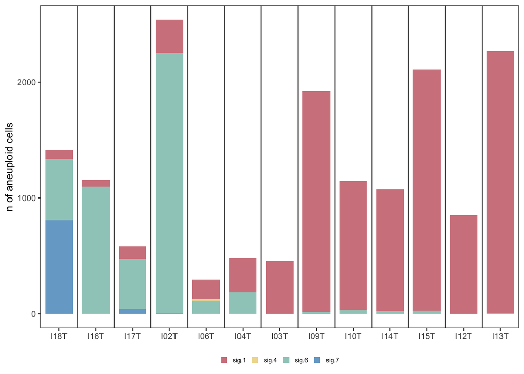

```r
df.cms <- left_join(df.cnv.filt, tsp.confidence, by=c('donor'='sample_id'))

df.cms.n <- df.cms %>% group_by(Donor, condition, rna_class, confidence.polarized, Top_NMF) %>% tally()
df.cms.n$esig <- factor(df.cms.n$Top_NMF, levels = paste0('sig.',c(1:10)))


ggplot(df.cms.n , aes(x=Donor, y=n, fill=esig)) +
  geom_bar(stat='identity')+
  facet_grid(.~Donor+condition , space='free_x',scales='free_x' ) +
  theme_bw(base_size=10)+
  theme(panel.grid = element_blank(),
        legend.position = 'bottom',
        legend.background = element_blank(),
        legend.text = element_text(size = 6),
        legend.key.size = unit(0.5, "lines"),
        plot.background=element_blank(),
        panel.background = element_blank(),
        legend.title = element_blank(),

        axis.title.x =  element_blank(),


        panel.spacing = unit(0, "lines"),
        strip.text = element_blank(),
        strip.background = element_blank())+ labs(y='n of aneuploid cells')+
  scale_fill_manual(values =
                      color.set, na.value = 'grey'
  )
```

## cell gCCS to tumour eCCS

Combine the cell-level genetic CCS calls to the pseudo-bulk eCCS calls and to the single cell NMF-signature assignments to show all three lines of evidence line up. Two samples had inclusive pseudo-bulk assignment and were removed in this step.

```r
tumour.cnv.arms <- df.cnv.filt %>%  dplyr::select(c("donor","barcode","gCMS","prob") |  starts_with("arm.") )

tumour.cnv.arms <- tumour.cnv.arms %>%
  reshape2::melt(id.vars=c("donor",'barcode','prob','gCMS'))

tumour.cnv.arms$band <- gsub("arm.","", tumour.cnv.arms$variable)

tumour.cnv.arms <- tumour.cnv.arms %>%
  dplyr::mutate(
    arm = substr(band, nchar(band), nchar(band)),
    chr = substr(band, 1, nchar(band) - 1)
  ) %>%
  dplyr::select(donor,barcode, prob, gCMS, chr, arm,band, value)

model.coeff <- data.frame('band'=gsub('arm.','',names(full_cnv_model$coefficients))) %>%  mutate(
  arm = substr(band, nchar(band), nchar(band)),
  chr = substr(band, 1, nchar(band) - 1)
) %>%   select(chr, arm, band)

tumour.cnv.model.arms <- tumour.cnv.arms %>% filter(band %in% model.coeff$band & !is.na(gCMS))
tumour.cnv.model.arms$Band <- factor(tumour.cnv.model.arms$band, levels = paste0(rep(1:21, each = 2), c("p", "q")) )

tumour.cnv.model.arms %>%
  group_by(donor) %>%
  summarise(
    most_common = names(sort(table(gCMS), decreasing = TRUE))[1],
    percentage = max(table(gCMS)) / n() * 100
  ) %>% summarise(mean_percentage=mean(percentage), min_perc=min(percentage), max_perc=max(percentage))
```

```
## # A tibble: 1 × 3
##   mean_percentage min_perc max_perc
##             <dbl>    <dbl>    <dbl>
## 1            84.2     59.1      100
```

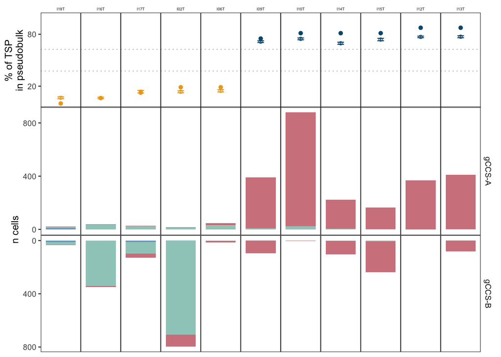

```r
tumour.cnv.model.arms$eCMS <- NA
tumour.cnv.model.arms$eCMS[tumour.cnv.model.arms$donor %in% tsp.confidence$Donor[tsp.confidence$rna_class == 'CCS-A']] <- 'CCS-A'
tumour.cnv.model.arms$eCMS[tumour.cnv.model.arms$donor %in% tsp.confidence$Donor[tsp.confidence$rna_class == 'CCS-B']] <- 'CCS-B'


tumour.cnv.model.arms.match <- tumour.cnv.model.arms %>% filter(!is.na(eCMS) & !is.na(gCMS)) #filter(eCMS == gCMS)
tumour.cnv.model.arms.match$Donor <- factor(tumour.cnv.model.arms.match$donor, levels = donor.confidence$Sample[order(donor.confidence$mean.conf)])




df.cms.n.filt <- df.cms %>% filter(barcode %in% tumour.cnv.model.arms.match$barcode) %>%
  group_by(Donor, condition, rna_class, confidence.polarized, Top_NMF, gCMS) %>% tally()
df.cms.n.filt$n[df.cms.n.filt$gCMS == 'CCS-B'] <- -df.cms.n.filt$n[df.cms.n.filt$gCMS == 'CCS-B']

df.cms.n.filt$esig <- factor(df.cms.n.filt$Top_NMF, levels = paste0('sig.',c(1:10)))


df.cms.n.filt$gCMS.f <- factor(paste0('g',df.cms.n.filt$gCMS), levels = rev(c('gCCS-B','gCCS-A')))




nmf.tally.gCMS.plot <-
         plot_grid(

           ggplot(tsp.confidence %>% filter(Donor %in% df.cms.n.filt$Donor), aes(x=Donor,  color=rna_class)) +

             geom_hline(yintercept = (10/16)*100, color='grey', linetype='dotted')+
             geom_hline(yintercept = (6/16)*100, color='grey', linetype='dotted')+

             geom_errorbar(aes(ymin = ci_low*100, ymax = ci_high*100), width = 0.2)  +

             geom_point(aes(y=confidence.polarized*100), size=1.5)+
             geom_point(aes(y=mean*100), shape=1)+

             facet_grid(. ~  Donor , space='free_x',scales='free_x') +

             theme_bw(base_size=10) +scale_color_manual(values =
                                                          c(
                                                            "CCS-A"="#04597C", "CCS-B"="#EDA71A"


                                                          ), na.value = 'grey'
             ) +labs(y='% of TSP\nin pseudobulk')+ theme(panel.grid = element_blank(),
                                                     axis.ticks.x = element_blank(),
                                                     axis.title.x = element_blank(),
                                                     axis.text.x = element_blank(),


                                                      strip.text.x = element_text(size = 4,margin = margin(t = 2, b = 2)),
                                                     plot.background=element_blank(),
                                                     panel.background = element_blank(),
                                                     panel.spacing = unit(0, "lines"),
                                                     strip.background = element_blank()) + guides(color='none')+
             scale_y_continuous(limits = c(0,100), breaks = c(20,80))


           ,NULL,
           ggplot(df.cms.n.filt, aes(x=Donor, y=n, fill=esig)) +
             geom_bar(stat='identity')+
             facet_grid(gCMS.f~Donor , space='free',scales='free' ) +
             theme_bw(base_size=10)+
             theme(panel.grid = element_blank(),
                   legend.position = 'bottom',
                   legend.background = element_blank(),
                   legend.text = element_text(size = 6),
                   legend.key.size = unit(0.5, "lines"),
                   plot.background=element_blank(),
                   panel.background = element_blank(),
                   legend.title = element_blank(),

                   axis.title.x =  element_blank(),
                   axis.text.x =  element_blank(),
                   axis.ticks.x =  element_blank(),


                   panel.spacing = unit(0, "lines"),
                   strip.text.x = element_blank(),
                   strip.background = element_blank()
             )+ labs(y='n cells')+
             guides(color='none',fill='none')+
             scale_y_continuous(breaks=c(-800,-400,0,400,800),labels = c(800,400,0,400,800)) +
             scale_fill_manual(values =
                                 color.set, na.value = 'grey'
             )
           ,ncol = 1, align = 'hv', axis = "rlbt",
           rel_heights =c(0.3,-0.05,0.7))
nmf.tally.gCMS.plot
```

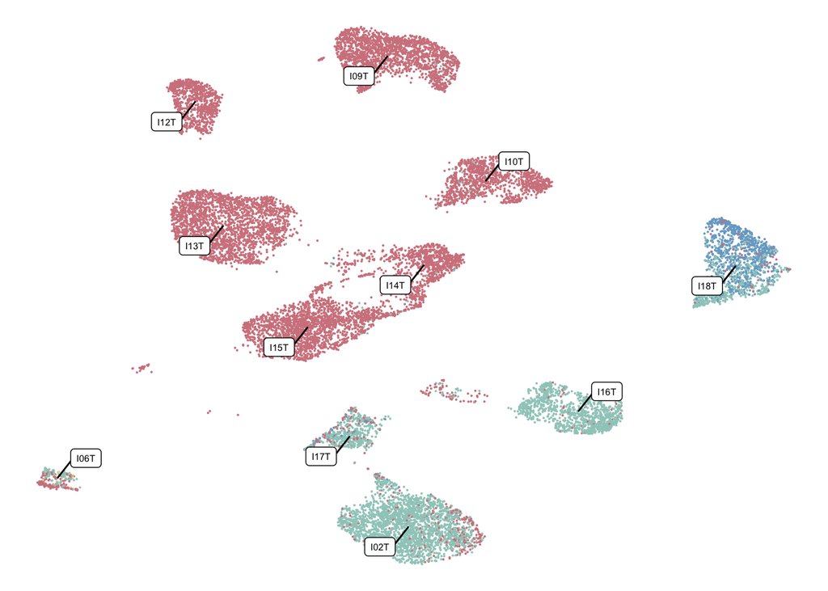

```r
ggsave(file.path(data.dir, "/results/fig/FIG3i.nmf.tally.gCMS.svg"), plot =
         nmf.tally.gCMS.plot
       , device = "svg", height = 65,width = 65, units = 'mm', dpi=72 )


ggplot(df.cms %>% filter(Donor %in% df.cms.n.filt$Donor), aes(x = umap_1, y = umap_2)) +

  geom_point(size=0.01, aes(color = Top_NMF)) +
  geom_label_repel(data = centroids %>% filter(donor %in% df.cms.n.filt$Donor), aes(x = x_centroid, y = y_centroid, label = donor),
                   size=2,   box.padding = 0.5, force = 0.5, max.time = 4,  min.segment.length = 0, max.overlaps =15) +
  theme_void() +  # removes all axes and background
  scale_color_manual(values =
                       color.set, na.value = 'white'


  ) +
  guides(fill='none',color='none')+
  theme(
    panel.border = element_blank(),
    plot.margin = margin(t = 0, r = 0, b = 0, l = 0),
    plot.background = element_blank()
  )
```